# Mini Data Analysis Milestone 2

Begin by loading your data and the tidyverse package below:

```r
suppressMessages(library(datateachr)) # <- might contain the data you picked!
suppressMessages(library(tidyverse))
```

# Task 1: Process and summarize your data (15 points)

### 1.1 (2.5 points)

First, write out the 4 research questions you defined in milestone 1 were. This will guide your work through milestone 2:

**Answer:**

1. Which types of trees have been planted the most in the past five years in each neighborhood? In other words, is there a trend in cultivated tree species in each area?
2. Is there any kind of relation between the height of trees (with the same type) and the neighborhood they have been planted in?
3. Within each neighborhood, do trees with a curb around them tend to have smaller diameters (in terms of growth)?
4. Could we validate within the dataset that the age of a tree directly relates to its diameter? Is it the same rate among all tree species, or it differs from one to another?

### 1.2 (10 points)

Now, for each of your four research questions, choose one task from options 1-4 (summarizing), and one other task from 4-8 (graphing). You should have 2 tasks done for each research question (8 total). Make sure it makes sense to do them! (e.g. don’t use a numerical variables for a task that needs a categorical variable.). Comment on why each task helps (or doesn’t!) answer the corresponding research question.

Ensure that the output of each operation is printed!

**Summarizing:**

1. Compute the *range*, *mean*, and *two other summary statistics* of **one numerical variable** across the groups of **one categorical variable** from your data.
2. Compute the number of observations for at least one of your categorical variables. Do not use the function `table()`!
3. Create a categorical variable with 3 or more groups from an existing numerical variable. You can use this new variable in the other tasks! *An example: age in years into “child, teen, adult, senior”.*
4. Based on two categorical variables, calculate two summary statistics of your choosing.

**Graphing:**

5. Create a graph out of summarized variables that has at least two geom layers.
6. Create a graph of your choosing, make one of the axes logarithmic, and format the axes labels so that they are “pretty” or easier to read.
7. Make a graph where it makes sense to customize the alpha transparency.
8. Create 3 histograms out of summarized variables, with each histogram having different sized bins. Pick the “best” one and explain why it is the best.

Make sure it’s clear what research question you are doing each operation for!

**Answer:**

#### Question 1: any trend in cultivated tree species in each area in past 5 years?

For this question, I choose **computing number of observations (option 2)** for the summarizing task. If we are going to compare between each area that which tree species is most popular, it would be suitable to know exactly how many trees were planted that year in neighborhoods. For example, if we’re saying 80% percent of planted trees were from ABIES in Kits and 70% in Downtown, the number of total planted trees would be of interest to be more accurate. Also, it is useful in comparison between tree species in different years.

```r
num_tr_nghbr <- vancouver_trees %>%
  # creating a variable year when trees are planted
  mutate(year_planted = as.character(substring(date_planted, 1, 4))) %>%
  # grouping trees by their neighborhood & year
  group_by(neighbourhood_name, year_planted) %>%
  # trees has planted in the pas 10 years
  filter(as.numeric(substring(Sys.Date(), 1, 4)) -
          as.numeric(year_planted) <= 5) %>%
  # counting number of trees per year in each neighborhood
  tally()

num_tr_nghbr
```

```
## # A tibble: 88 × 3
## # Groups:   neighbourhood_name [22]
##    neighbourhood_name year_planted     n
##    <chr>              <chr>        <int>
##  1 ARBUTUS-RIDGE      2016            51
##  2 ARBUTUS-RIDGE      2017            58
##  3 ARBUTUS-RIDGE      2018            57
##  4 ARBUTUS-RIDGE      2019            43
##  5 DOWNTOWN           2016            29
##  6 DOWNTOWN           2017            42
##  7 DOWNTOWN           2018             1
##  8 DOWNTOWN           2019            53
##  9 DUNBAR-SOUTHLANDS  2016            78
## 10 DUNBAR-SOUTHLANDS  2017            54
## # … with 78 more rows
```

I choose **option 6 (logarithmic scale and formatting the axes labels)** for this question. The plot is trying to convey the summarized variable in a way that is easy to compare the number of planted trees across years and neighborhoods.

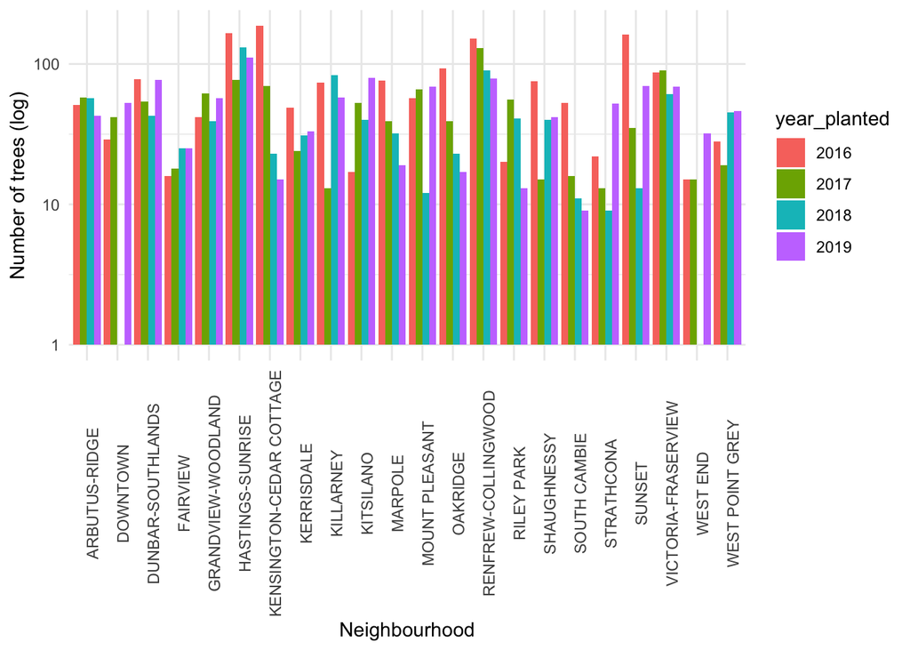

```r
hist_tr_nghbr <- num_tr_nghbr %>%
  ggplot(aes(neighbourhood_name, n)) +
  geom_col(aes(fill=year_planted), position = "dodge") +
  scale_y_log10() +
  xlab("Neighbourhood") +
  ylab("Number of trees (log)") +
  theme_minimal() +
  theme(axis.text.x = element_text(angle = 90))

print(hist_tr_nghbr)
```

#### Question 2: Any relation between the height of trees (with the same type) and the neighborhood?

I choose **option 1: summary statistics** for this question. I calculated mean, min, max, median, and standard deviation of height across neighborhoods and tree species. It would be useful to know the mean and other statistics on the height when we’re comparing it between two neighborhoods to detect differences.

```r
height_nghbr <- vancouver_trees %>%
  # putting together species and neighborhood
  group_by(neighbourhood_name, genus_name) %>%
  summarise(mean_height= mean(height_range_id),  # mean
            min_height = min(height_range_id), # min
            max_height =  max(height_range_id), # max
            median_height = median(height_range_id), # median
            std_height = sd(height_range_id), .groups = 'drop')

  #filter(genus_name == "X") ** by adding this line you can see the differences in height statistics for a species across neighborhoods **

height_nghbr
```

```
## # A tibble: 1,303 × 7
##    neighbourhood_name genus_name  mean_height min_height max_height median_height
##    <chr>              <chr>             <dbl>      <dbl>      <dbl>         <dbl>
##  1 ARBUTUS-RIDGE      ABIES              3.11          2          7             2
##  2 ARBUTUS-RIDGE      ACER               2.69          1          9             2
##  3 ARBUTUS-RIDGE      AESCULUS           4.67          1          8             5
##  4 ARBUTUS-RIDGE      AMELANCHIER        1.95          1          4             2
##  5 ARBUTUS-RIDGE      BETULA             5.04          1          7             5
##  6 ARBUTUS-RIDGE      CALOCEDRUS         1             1          1             1
##  7 ARBUTUS-RIDGE      CARPINUS           2.02          1          6             2
##  8 ARBUTUS-RIDGE      CATALPA            2.8           2          6             2
##  9 ARBUTUS-RIDGE      CEDRUS             4.73          2          9             5
## 10 ARBUTUS-RIDGE      CELTIS             1             1          1             1
## # … with 1,293 more rows, and 1 more variable: std_height <dbl>
```

Since we have many types of tree species in the data, I focused only on the family of trees instead of species and considered the top 3 that are most populated in the dataset to investigate the question. I plotted the density distribution of the height of the tree families across neighborhoods to explore whether there are any differences in the distributions among neighborhoods or not.

```r
top_genus <- vancouver_trees %>%
  group_by(genus_name) %>%
  tally() %>%
  arrange(desc(n)) %>%
  top_n(3)
```

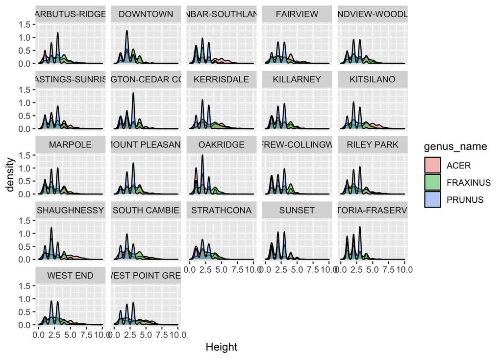

```r
height_dist_nghbr <- vancouver_trees %>%
  filter(genus_name %in% top_genus$genus_name) %>%
  group_by(genus_name) %>%
  ggplot(aes(height_range_id)) +
  geom_density(aes(fill=genus_name), alpha = 0.4) +
  facet_wrap(~ neighbourhood_name) +
  xlab("Height")

height_dist_nghbr
```

It seems distributions do not vary a lot for each tree family across neighborhoods!

#### Question 3: curb affects diameters?

For this research question, It would be good to know how many trees have curbs around them and how many do not. Because it would not be a fair comparison if we have a lot of observations from one population and few samples from another one. It turns out to be a case in our question! We do have fewer samples for `curb=NO` against `curb=YES` in each neighborhood.

```r
count_curbed <- vancouver_trees %>%
  group_by(neighbourhood_name, curb) %>%
  tally() # counting  numbers of trees with and without curb in each neighborhood

count_curbed
```

```
## # A tibble: 44 × 3
## # Groups:   neighbourhood_name [22]
##    neighbourhood_name curb      n
##    <chr>              <chr> <int>
##  1 ARBUTUS-RIDGE      N       500
##  2 ARBUTUS-RIDGE      Y      4669
##  3 DOWNTOWN           N        69
##  4 DOWNTOWN           Y      5090
##  5 DUNBAR-SOUTHLANDS  N      1797
##  6 DUNBAR-SOUTHLANDS  Y      7618
##  7 FAIRVIEW           N       203
##  8 FAIRVIEW           Y      3799
##  9 GRANDVIEW-WOODLAND N       612
## 10 GRANDVIEW-WOODLAND Y      6091
## # … with 34 more rows
```

I plotted the distribution of trees diameter with and without curbs in each neighborhood. So, it can help us identify does having a curb affects the tree’s diameter. As shown in the plot, there is no significant difference between the distributions and their means in most neighborhoods. Also, it is worth mentioning that numbers of positive (with a curb) and negative are not the same! If we had more negative samples, we could answer the question better.

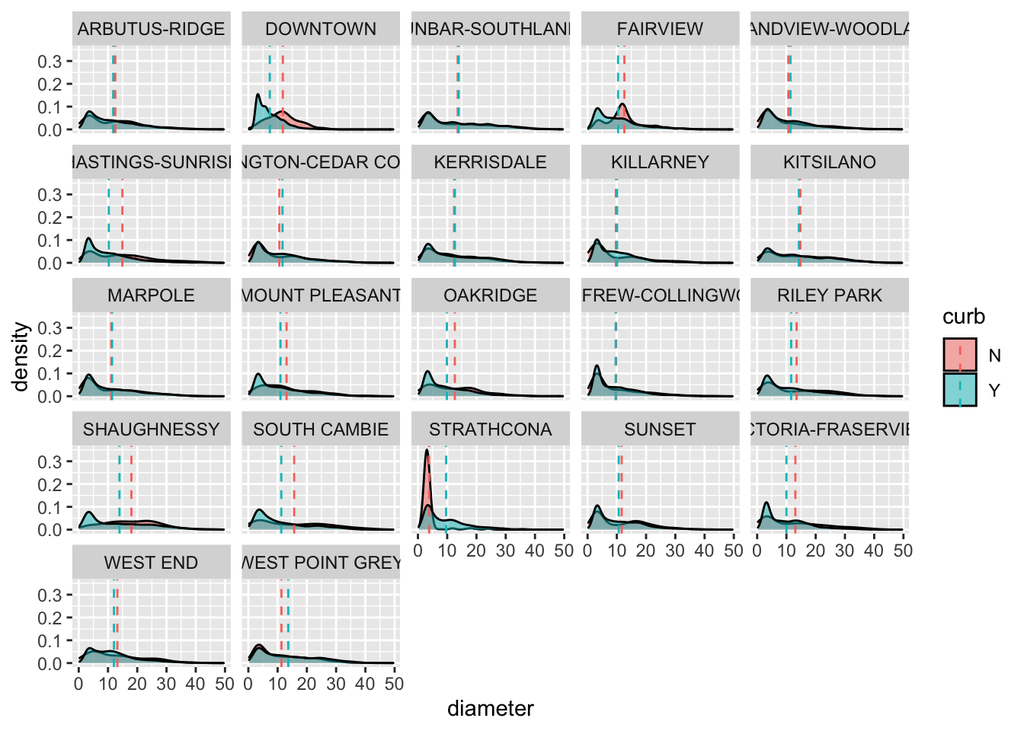

```r
means <- vancouver_trees %>%
  filter(0 < diameter & diameter < 50) %>%
  group_by(neighbourhood_name, curb) %>%
  # calculating mean of diameter of trees in each neighborhood based on curb
  summarise(mean_dmtr = mean(diameter), .groups = 'drop')

dist_dmtr_nghbr <- vancouver_trees %>%
  filter(0 < diameter & diameter < 50) %>%
  group_by(neighbourhood_name) %>%
  ggplot(aes(diameter)) +
  geom_density(aes(fill=curb), alpha=0.5) +
  geom_vline(data=means, aes(xintercept=means$mean_dmtr, color=curb),
             linetype="dashed") +
  facet_wrap(~ neighbourhood_name)

dist_dmtr_nghbr
```

#### Question 4: Age Vs diameter across tree species?

I created a categorical variable named age_cat, based on the age of trees. This new variable has five categories: `Youth, Mature, Middle Age, Senior, Ancient`. The reason for creating this was to first, have better visualization of age against diameter as scatter plot for this question was not that informative, and second, investigate how diameter is distributed in each period of age.

```r
van_tree_catAge <- vancouver_trees %>%
  # calculating age of trees with Sys.Date() and date_planted variable
  mutate(age = as.numeric(substring(Sys.Date(), 1, 4))-
                 as.numeric(substring(date_planted, 1, 4))) %>%
  # creating categorical variable based on age!
  mutate(age_cat = cut(age,
                breaks = c(0, 10, 20, 30, 40, Inf),
                labels = c("Youth","Mature","Middle Age","Senior","Ancient"))) %>%
  select(tree_id, age, age_cat, everything())

head(van_tree_catAge)
```

```
## # A tibble: 6 × 22
##   tree_id   age age_cat    civic_number std_street genus_name species_name
##     <dbl> <dbl> <fct>             <dbl> <chr>      <chr>      <chr>
## 1  149556    22 Middle Age          494 W 58TH AV  ULMUS      AMERICANA
## 2  149563    25 Middle Age          450 W 58TH AV  ZELKOVA    SERRATA
## 3  149579    28 Middle Age         4994 WINDSOR ST STYRAX     JAPONICA
## 4  149590    25 Middle Age          858 E 39TH AV  FRAXINUS   AMERICANA
## 5  149604    28 Middle Age         5032 WINDSOR ST ACER       CAMPESTRE
## 6  149616    NA <NA>                585 W 61ST AV  PYRUS      CALLERYANA
## # … with 15 more variables: cultivar_name <chr>, common_name <chr>,
## #   assigned <chr>, root_barrier <chr>, plant_area <chr>,
## #   on_street_block <dbl>, on_street <chr>, neighbourhood_name <chr>,
## #   street_side_name <chr>, height_range_id <dbl>, diameter <dbl>, curb <chr>,
## #   date_planted <date>, longitude <dbl>, latitude <dbl>
```

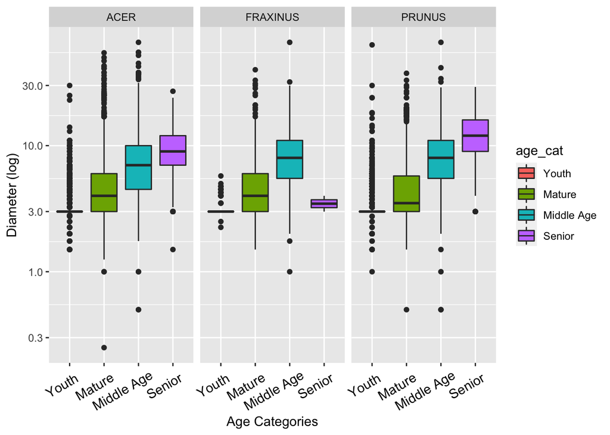

```r
age_diamtr_rel <- van_tree_catAge %>%
  # filtering top 3 families of trees
  filter(genus_name %in% top_genus$genus_name) %>%
  # from the previous milestone, we have very few data points with diameter > 75
  filter(0 < diameter & diameter < 75) %>%
  # removing NA values
  filter(!is.na(diameter) & !is.na(age)) %>%
  ggplot(aes(age_cat,  diameter)) +
  geom_boxplot(aes(fill=age_cat)) +
  theme(axis.text.x = element_text(color = "black", size=11, angle=30, vjust=.8, hjust=0.8)) +
  scale_y_log10() +
  xlab("Age Categories") +
  ylab("Diameter (log)") +
  facet_wrap(~ genus_name)

age_diamtr_rel
```

### 1.3 (2.5 points)

Based on the operations that you’ve completed, how much closer are you to answering your research questions? Think about what aspects of your research questions remain unclear. Can your research questions be refined, now that you’ve investigated your data a bit more? Which research questions are yielding interesting results?

**Answer:**

# Task 2: Tidy your data (12.5 points)

In this task, we will do several exercises to reshape our data. The goal here is to understand how to do this reshaping with the `tidyr` package.

A reminder of the definition of *tidy* data:

- Each row is an **observation**
- Each column is a **variable**
- Each cell is a **value**

*Tidy’ing* data is sometimes necessary because it can simplify computation. Other times it can be nice to organize data so that it can be easier to understand when read manually.

### 2.1 (2.5 points)

Based on the definition above, can you identify if your data is tidy or untidy? Go through all your columns, or if you have >8 variables, just pick 8, and explain whether the data is untidy or tidy.

**Answer:**

Let’s start with looking at the data again and see if it is satisfied with our criteria of tidy data.

```r
glimpse(vancouver_trees)
```

```
## Rows: 146,611
## Columns: 20
## $ tree_id            <dbl> 149556, 149563, 149579, 149590, 149604, 149616, 149…
## $ civic_number       <dbl> 494, 450, 4994, 858, 5032, 585, 4909, 4925, 4969, 7…
## $ std_street         <chr> "W 58TH AV", "W 58TH AV", "WINDSOR ST", "E 39TH AV"…
## $ genus_name         <chr> "ULMUS", "ZELKOVA", "STYRAX", "FRAXINUS", "ACER", "…
## $ species_name       <chr> "AMERICANA", "SERRATA", "JAPONICA", "AMERICANA", "C…
## $ cultivar_name      <chr> "BRANDON", NA, NA, "AUTUMN APPLAUSE", NA, "CHANTICL…
## $ common_name        <chr> "BRANDON ELM", "JAPANESE ZELKOVA", "JAPANESE SNOWBE…
## $ assigned           <chr> "N", "N", "N", "Y", "N", "N", "N", "N", "N", "N", "…
## $ root_barrier       <chr> "N", "N", "N", "N", "N", "N", "N", "N", "N", "N", "…
## $ plant_area         <chr> "N", "N", "4", "4", "4", "B", "6", "6", "3", "3", "…
## $ on_street_block    <dbl> 400, 400, 4900, 800, 5000, 500, 4900, 4900, 4900, 7…
## $ on_street          <chr> "W 58TH AV", "W 58TH AV", "WINDSOR ST", "E 39TH AV"…
## $ neighbourhood_name <chr> "MARPOLE", "MARPOLE", "KENSINGTON-CEDAR COTTAGE", "…
## $ street_side_name   <chr> "EVEN", "EVEN", "EVEN", "EVEN", "EVEN", "ODD", "ODD…
## $ height_range_id    <dbl> 2, 4, 3, 4, 2, 2, 3, 3, 2, 2, 2, 5, 3, 2, 2, 2, 2, …
## $ diameter           <dbl> 10.00, 10.00, 4.00, 18.00, 9.00, 5.00, 15.00, 14.00…
## $ curb               <chr> "N", "N", "Y", "Y", "Y", "Y", "Y", "Y", "Y", "Y", "…
## $ date_planted       <date> 1999-01-13, 1996-05-31, 1993-11-22, 1996-04-29, 19…
## $ longitude          <dbl> -123.1161, -123.1147, -123.0846, -123.0870, -123.08…
## $ latitude           <dbl> 49.21776, 49.21776, 49.23938, 49.23469, 49.23894, 4…
```

As we can see, each row is an observation unit of trees, and each variable is a record from them. As far as my research questions were, we didn’t need any re-formatting (wide to long and vice versa) to make our analysis more straightforward and more efficient since we could put the names of our variables to the axis of plots. Another criteria that the dataset meets is that each cell represents a value. So, our data is indeed tidy.

### 2.2 (5 points)

Now, if your data is tidy, untidy it! Then, tidy it back to it’s original state.

If your data is untidy, then tidy it! Then, untidy it back to it’s original state.

Be sure to explain your reasoning for this task. Show us the “before” and “after”.

**Answer:**

First, start with untidy-ing data. For this purpose, I combine `diameter` and `height_range_id` variables as `dimension_name` and their values to `dimension_value` to make a long data version. As shown below, now the dimension_name variable is no longer a record of our data and doesn’t represent a value, making it untidy! With the below dataset, answering questions 3 and 4 would be hard.

```r
untidey_data <- vancouver_trees %>%
  pivot_longer(
    cols = c(diameter, height_range_id),
    names_to = "dimension_name",
    values_to = "dimension_value"
  ) %>%
  select(tree_id, dimension_name, dimension_value, everything())

head(untidey_data)
```

```
## # A tibble: 6 × 20
##   tree_id dimension_name  dimension_value civic_number std_street genus_name
##     <dbl> <chr>                     <dbl>        <dbl> <chr>      <chr>
## 1  149556 diameter                     10          494 W 58TH AV  ULMUS
## 2  149556 height_range_id               2          494 W 58TH AV  ULMUS
## 3  149563 diameter                     10          450 W 58TH AV  ZELKOVA
## 4  149563 height_range_id               4          450 W 58TH AV  ZELKOVA
## 5  149579 diameter                      4         4994 WINDSOR ST STYRAX
## 6  149579 height_range_id               3         4994 WINDSOR ST STYRAX
## # … with 14 more variables: species_name <chr>, cultivar_name <chr>,
## #   common_name <chr>, assigned <chr>, root_barrier <chr>, plant_area <chr>,
## #   on_street_block <dbl>, on_street <chr>, neighbourhood_name <chr>,
## #   street_side_name <chr>, curb <chr>, date_planted <date>, longitude <dbl>,
## #   latitude <dbl>
```

Now let’s try to make the data back to tidy again!

```r
tidy_data <- untidey_data %>%
  pivot_wider(
    id_cols = c(-dimension_name, -dimension_value),
    names_from = dimension_name,
    values_from = dimension_value) %>%
  select(tree_id, diameter, height_range_id, everything())
head(tidy_data)
```

```
## # A tibble: 6 × 20
##   tree_id diameter height_range_id civic_number std_street genus_name
##     <dbl>    <dbl>           <dbl>        <dbl> <chr>      <chr>
## 1  149556       10               2          494 W 58TH AV  ULMUS
## 2  149563       10               4          450 W 58TH AV  ZELKOVA
## 3  149579        4               3         4994 WINDSOR ST STYRAX
## 4  149590       18               4          858 E 39TH AV  FRAXINUS
## 5  149604        9               2         5032 WINDSOR ST ACER
## 6  149616        5               2          585 W 61ST AV  PYRUS
## # … with 14 more variables: species_name <chr>, cultivar_name <chr>,
## #   common_name <chr>, assigned <chr>, root_barrier <chr>, plant_area <chr>,
## #   on_street_block <dbl>, on_street <chr>, neighbourhood_name <chr>,
## #   street_side_name <chr>, curb <chr>, date_planted <date>, longitude <dbl>,
## #   latitude <dbl>
```

Our data is tidy again!

### 2.3 (5 points)

Now, you should be more familiar with your data, and also have made progress in answering your research questions. Based on your interest, and your analyses, pick 2 of the 4 research questions to continue your analysis in milestone 3, and explain your decision.

Try to choose a version of your data that you think will be appropriate to answer these 2 questions in milestone 3. Use between 4 and 8 functions that we’ve covered so far (i.e. by filtering, cleaning, tidy’ing, dropping irrelvant columns, etc.).

**Answer:**

Based on what I have done in research questions, I would like to continue my work on question 1 (trends in cultivated tree species in each neighborhood past five years) and question 4 (Age versus diameter across tree species). I think these questions are more likely to yield correct and interesting answers. Unbalanced classes of data in the two other questions are barriers to producing concrete results. Also, we somewhat reached the answers we wanted based on the summarized statistics and plots. Besides, I am excited to explore the relation between diameter and age for each species in question 4 by fitting linear models and comparing the coefficients. For question 1, I am curious about how to plot the information in a way to see trends in each neighborhood.

```r
vancouver_trees_v2 <- vancouver_trees %>%
  # Only selecting the variables we need for the next milestone
  select(tree_id, genus_name, neighbourhood_name, diameter, date_planted) %>%
  # Filtering outlier diameters
  filter(diameter > 0 & diameter < 75) %>%
  # Removing NA records
  filter(!is.na(diameter) & !is.na(date_planted) & !is.na(diameter)) %>%
  # Creating year_planted based on date_planted
  mutate(year_planted = as.numeric(substring(date_planted, 1, 4))) %>%
  # Calculating age of each tree
  mutate(age = as.numeric(substring(Sys.Date(), 1, 4)) - year_planted) %>%
  # Removing date_planted variable
  select(tree_id, genus_name, neighbourhood_name, diameter, year_planted, age)%>%
  group_by(neighbourhood_name, year_planted) %>%
  # Counting number of trees in each neighborhood as we need those numbers of question number 1
  mutate(n_nghbr = n()) %>%
  ungroup()


head(vancouver_trees_v2)
```

```
## # A tibble: 6 × 7
##   tree_id genus_name neighbourhood_name       diameter year_planted   age n_nghbr
##     <dbl> <chr>      <chr>                       <dbl>        <dbl> <dbl>   <int>
## 1  149556 ULMUS      MARPOLE                        10         1999    22     161
## 2  149563 ZELKOVA    MARPOLE                        10         1996    25     152
## 3  149579 STYRAX     KENSINGTON-CEDAR COTTAGE        4         1993    28     302
## 4  149590 FRAXINUS   KENSINGTON-CEDAR COTTAGE       18         1996    25     368
## 5  149604 ACER       KENSINGTON-CEDAR COTTAGE        9         1993    28     302
## 6  149617 ACER       KENSINGTON-CEDAR COTTAGE       15         1993    28     302
```

*When you are done, knit an `md` file. This is what we will mark! Make sure to open it and check that everything has knitted correctly before submitting your tagged release.*

### Attribution

Thanks to Victor Yuan for mostly putting this together.